# Project 1

Sai Jaligama

3/26/2020

```r
simCorn <- function(overallEffect = 0, fertilizerEffect = c(0,0,0), rowEffect = c(0,0,0), colEffect = c(0,0,0), seed =NULL,dist = rnorm, ...){

  if (is.character(overallEffect)){
    stop("overallEffect should be an integer")
  }

  check_shape_type(fertilizerEffect)
  check_shape_type(rowEffect)
  check_shape_type(colEffect)
  if (!is.function(dist)){
    stop("dist variable should be a function")
  }

  dist1 <- function(dist3, ...){
    return(dist3(27, ...))
  }

  dist_new <-dist1(dist, ...)

  if (is.null(seed)){
    set.seed(NULL)
  }
  else if (seed%%1 == 0){
    set.seed(seed)
  }
  else {
    stop("You have to enter an integer")
  }



  Y <- list()
  y_inc <- 1
  main_df <- data.frame(Fertilizer = c(0), Row = c(0), Column = c(0),Yield = I(c(0)))
  for (i in 1:length(fertilizerEffect)){
    for (j in 1:length(rowEffect)){
      for (k in 1:length(colEffect)){
        Y[y_inc] <- overallEffect  +  fertilizerEffect[i]+ rowEffect[j] + colEffect[k] + dist_new[y_inc]
        main_df[y_inc, ] <- c(fertilizerEffect[i],rowEffect[j],colEffect[k],Y[y_inc])
        y_inc <- y_inc+1
      }
    }

  }
  return(main_df)
}

check_shape_type <- function(thing){

  if (length(thing)!=3){
    name <- deparse(substitute(thing))
    stop("there should be 3 values in ",name)
  }

  for (i in thing) {
    if (is.character(i) || is.integer(thing)){
      name <- deparse(substitute(thing))
      stop("values should be integers in ",name)
    }
    else{
      dontneedthis<-1
    }
  }
}
y <- simCorn()
y
```

```
##    Fertilizer Row Column        Yield
## 1           0   0      0 -1.13257....
## 2           0   0      0 -0.09143....
## 3           0   0      0 -1.27314....
## 4           0   0      0 0.399074....
## 5           0   0      0 1.148878....
## 6           0   0      0 0.210458....
## 7           0   0      0 -0.41874....
## 8           0   0      0 -0.10345....
## 9           0   0      0 0.833014....
## 10          0   0      0 0.100875....
## 11          0   0      0 -1.30765....
## 12          0   0      0 -0.89775....
## 13          0   0      0 -0.89071....
## 14          0   0      0 0.049875....
## 15          0   0      0 -0.14909....
## 16          0   0      0 0.384547....
## 17          0   0      0 -0.60899....
## 18          0   0      0 -0.65737....
## 19          0   0      0 0.900161....
## 20          0   0      0 -0.97048....
## 21          0   0      0 -0.32333....
## 22          0   0      0 0.560319....
## 23          0   0      0 -0.64810....
## 24          0   0      0 -0.36252....
## 25          0   0      0 -0.33873....
## 26          0   0      0 -0.23078....
## 27          0   0      0 0.587958....
```

```r
y <- simCorn(overallEffect=10,seed=2123,dist=rgamma,shape=2)
y
```

```
##    Fertilizer Row Column        Yield
## 1           0   0      0 10.43356....
## 2           0   0      0 10.69145....
## 3           0   0      0 12.02857....
## 4           0   0      0 13.23706....
## 5           0   0      0 11.76883....
## 6           0   0      0 11.03098....
## 7           0   0      0 10.58469....
## 8           0   0      0 11.62609....
## 9           0   0      0 12.16015....
## 10          0   0      0 12.26473....
## 11          0   0      0 10.81124....
## 12          0   0      0 13.21637....
## 13          0   0      0 11.82637....
## 14          0   0      0 11.24932....
## 15          0   0      0 14.25812....
## 16          0   0      0 11.69989....
## 17          0   0      0 10.74144....
## 18          0   0      0 10.90126....
## 19          0   0      0 12.41633....
## 20          0   0      0 12.61935....
## 21          0   0      0 10.67936....
## 22          0   0      0 12.06666....
## 23          0   0      0 10.73448....
## 24          0   0      0 11.26371....
## 25          0   0      0 11.89691....
## 26          0   0      0 11.29630....
## 27          0   0      0 13.51039....
```

```r
mu <- 7
alpha <- c(1,2,3)
beta <- c(2,2,1)
gamma <- c(3,3,2)
y <- simCorn(overallEffect=mu, fertilizerEffect=alpha, rowEffect=beta, colEffect=gamma,
             seed=29429, rnorm, mean=3, sd=2)
y
```

```
##    Fertilizer Row Column        Yield
## 1           1   2      3 19.89853....
## 2           1   2      3 13.79692....
## 3           1   2      2 17.08962....
## 4           1   2      3 15.72327....
## 5           1   2      3 15.48535....
## 6           1   2      2 13.91214....
## 7           1   1      3 15.21220....
## 8           1   1      3 14.13080....
## 9           1   1      2 15.46416....
## 10          2   2      3 16.98774....
## 11          2   2      3 16.91729....
## 12          2   2      2 14.78952....
## 13          2   2      3 19.65712....
## 14          2   2      3 16.68767....
## 15          2   2      2 16.19706....
## 16          2   1      3 15.18287....
## 17          2   1      3 18.03785....
## 18          2   1      2 12.03772....
## 19          3   2      3 18.22543....
## 20          3   2      3 12.25992....
## 21          3   2      2 15.53943....
## 22          3   2      3 15.93062....
## 23          3   2      3 18.98555....
## 24          3   2      2 18.44485....
## 25          3   1      3 13.82942....
## 26          3   1      3 16.63682....
## 27          3   1      2 13.81109....
```

**help(simCorn)**

**Description** simCorn is a user defined function used to simulate a dataframe for measuring the yield produced, given the type of soil and fertilizer and error distribution.

**Usage** simcorn(overallEffect = 0, fertilizerEffect = c(0,0,0), rowEffect = c(0,0,0), colEffect = c(0,0,0), seed =NULL,dist = rnorm, …)

**Arguments** overallEffect <- mean of the effect of soil and fertilizer in the yield

fertilizerEffect <- which is the specified fertilizer effect with a default value of 0. This is a numeric vector of length three that contains the values β1, β2, and β3, with a default value equal to c(0,0,0).

rowEffect <- which is the specified row effect. This is a numeric vector of length three that contains the values β1, β2, and β3, with a default value equal to c(0,0,0).

colEffect <- which is the specified column effect with a default value equal to 0. This is a numeric vector of length three that contains the values β1, β2, and β3, with a default value equal to c(0,0,0).

seed <- which is an option random seed with a default value equal to NULL.

dist <- t should be a function name that generates a random sample from a distribution in R. The default function name should be rnorm.

… additional arguments used for specifying the distribution of the error terms in the model.

**Details** This function uses the effect of fertilizer, row and column given distributionof the error and mean of the yield to produce a dataframe. This dataframe contains combinations of Yield, fertilizereffect, roweffect, coleffect.

**Value** A data frame containing Yield, fertilizereffect, roweffect, coleffect.

##help(check_shape_type)

**Description** This function checks type and length of the passed argument(vector). This function can accept values fertilizereffect, roweffect, coleffect. This function is written only to write the main problem a bit more effeceiently.

**Usage** check_shape_type(thing)

**Arguments** thing <- the vector needed to be tested.

**Details** The function uses if conditions to first check if the length of the vector is three and then checks if the values in the vector are integers or not.

**Value** No values is returned.

```r
#1
p_values <- c()
for (i in 1:100){
  y <- simCorn(overallEffect=10, fertilizerEffect = c(0,0,0), rowEffect = c(0,0,0), colEffect = c(0,0,0), dist = rnorm,mean=0,sd=1)
  fitCorn <- lm(Yield ~ Fertilizer + Row + Column, data = y)
  pValue <- anova(fitCorn)$"Pr(>F)"[1]
  p_values[i] <- pValue

}
p_values
```

```
##   [1] NA NA NA NA NA NA NA NA NA NA NA NA NA NA NA NA NA NA NA NA NA NA NA NA NA
##  [26] NA NA NA NA NA NA NA NA NA NA NA NA NA NA NA NA NA NA NA NA NA NA NA NA NA
##  [51] NA NA NA NA NA NA NA NA NA NA NA NA NA NA NA NA NA NA NA NA NA NA NA NA NA
##  [76] NA NA NA NA NA NA NA NA NA NA NA NA NA NA NA NA NA NA NA NA NA NA NA NA NA
```

[figure not shown]

```r
hist(p_values, xlim = range(0,1),breaks = seq(0,1,0.05),col = "blue", main = paste("Simulation 1 (",length(p_values[p_values<0.05]),"% Less Than 0.05)"))
abline(v=0.05,col="red")
```

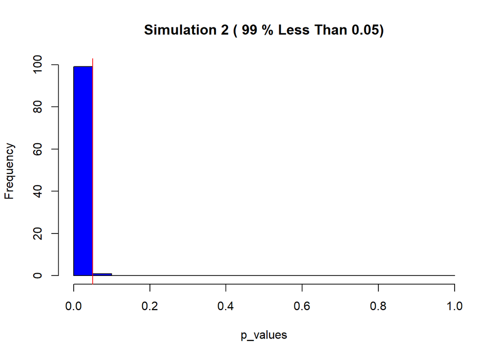

```r
#2
p_values <- c()
for (i in 1:100){
  y <- simCorn(overallEffect=10, fertilizerEffect = c(1,2,3), rowEffect = c(0,0,1), colEffect = c(0,0,1),mean=0,sd=1)
  fitCorn <- lm(Yield ~ Fertilizer + Row + Column, data=y)
  pValue <- anova(fitCorn)$"Pr(>F)"[1]
  p_values[i] <- pValue

}
hist(p_values, xlim = range(0,1),breaks = seq(0,1,0.05),col = "blue", main = paste("Simulation 2 (",length(p_values[p_values<0.05]),"% Less Than 0.05)"))
abline(v=0.05,col="red")
```

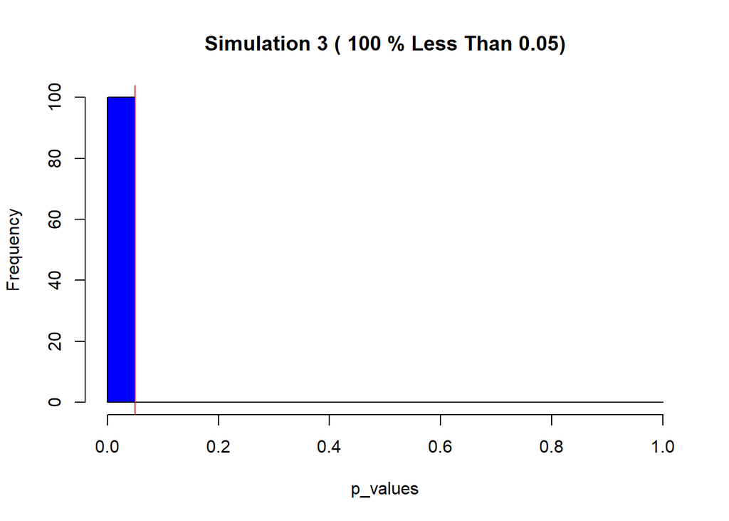

```r
#3
p_values <- c()
for (i in 1:100){
  y <- simCorn(overallEffect=10, fertilizerEffect = c(1,2,3), rowEffect = c(1,0,1), colEffect = c(0,1,1),mean=0,sd=1)
  fitCorn <- lm(Yield ~ Fertilizer + Row + Column, data=y)
  pValue <- anova(fitCorn)$"Pr(>F)"[1]
  p_values[i] <- pValue

}
hist(p_values, xlim = range(0,1),breaks = seq(0,1,0.05),col = "blue", main = paste("Simulation 3 (",length(p_values[p_values<0.05]),"% Less Than 0.05)"))
abline(v=0.05,col="red")
```

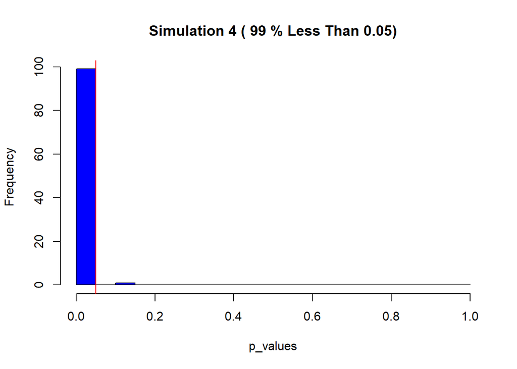

```r
#4
p_values <- c()
for (i in 1:100){
  y <- simCorn(overallEffect=10,c(1,2,3),c(0,1,0),c(0,1,0), mean=0,sd=1)
  fitCorn <- lm(Yield ~ Fertilizer + Row + Column, data=y)
  pValue <- anova(fitCorn)$"Pr(>F)"[1]
  p_values[i] <- pValue

}
hist(p_values, xlim = range(0,1),breaks = seq(0,1,0.05),col = "blue", main = paste("Simulation 4 (",length(p_values[p_values<0.05]),"% Less Than 0.05)"))
abline(v=0.05,col="red")
```

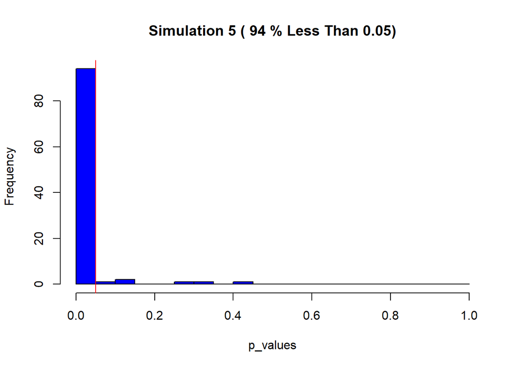

```r
#5
p_values <- c()
for (i in 1:100){
  y <- simCorn(overallEffect=10,c(1,2,3),c(0,0,1),c(0,0,1), dist = rexp, rate=1)
  fitCorn <- lm(Yield ~ Fertilizer + Row + Column, data=y)
  pValue <- anova(fitCorn)$"Pr(>F)"[1]
  p_values[i] <- pValue

}
hist(p_values, xlim = range(0,1),breaks = seq(0,1,0.05),col = "blue", main = paste("Simulation 5 (",length(p_values[p_values<0.05]),"% Less Than 0.05)"))
abline(v=0.05,col="red")
```

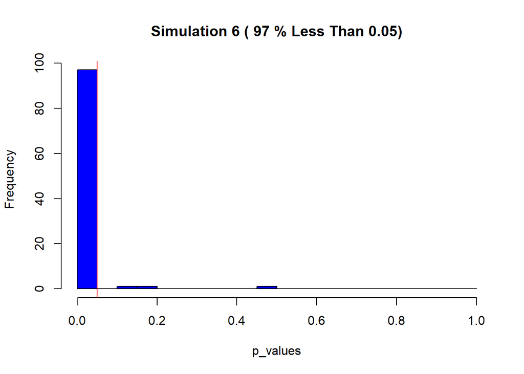

```r
#6
p_values <- c()
for (i in 1:100){
  y <- simCorn(overallEffect=10,c(1,2,3),c(1,0,1),c(0,1,1), dist = rexp, rate=1)
  fitCorn <- lm(Yield ~ Fertilizer + Row + Column, data=y)
  pValue <- anova(fitCorn)$"Pr(>F)"[1]
  p_values[i] <- pValue

}
hist(p_values, xlim = range(0,1),breaks = seq(0,1,0.05),col = "blue", main = paste("Simulation 6 (",length(p_values[p_values<0.05]),"% Less Than 0.05)"))
abline(v=0.05,col="red")
```

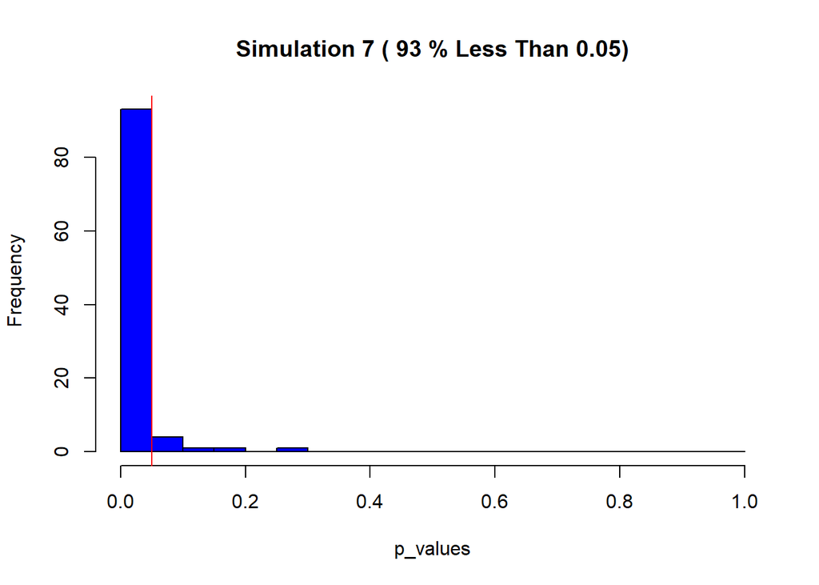

```r
p_values <- c()
for (i in 1:100){
  y <- simCorn(overallEffect=10,c(1,2,3),c(0,1,0),c(0,1,0), dist = rexp, rate=1)
  fitCorn <- lm(Yield ~ Fertilizer + Row + Column, data=y)
  pValue <- anova(fitCorn)$"Pr(>F)"[1]
  p_values[i] <- pValue

}
hist(p_values, xlim = range(0,1),breaks = seq(0,1,0.05),col = "blue", main = paste("Simulation 7 (",length(p_values[p_values<0.05]),"% Less Than 0.05)"))
abline(v=0.05,col="red")
```